# Student Experience Shifts

Tony Daza

2023-05-10

**Importing Data**

# LEAP variables

```r
school_leap <- full %>% select(c(2,3,5,6,7, 9:16, 109:129, 131:132, 151:155, 164:166, 280:285))
```

```r
leaps_rank_cols <- c("leaps_rank_affirmation", "leaps_rank_anytime_anywhere", "leaps_rank_connection", "leaps_rank_customization", "leaps_rank_high_expectations", "leaps_rank_relevance", "leaps_rank_rigorous_learning", "leaps_rank_self_direction", "leaps_rank_social_consciousness", "leaps_rank_whole_child")

leaps_cols <- c("leaps_affirmation", "leaps_anytime_anywhere", "leaps_connection", "leaps_customization", "leaps_high_expectations", "leaps_relevance", "leaps_rigorous_learning", "leaps_self_direction", "leaps_social_consciousness", "leaps_whole_child")

# Realized this was not necessary
for (col_name in leaps_rank_cols) {
  school_leap[, col_name][school_leap[, col_name] == 0] <- NA
}
```

## Distribution of LEAP Implementation

### Counts

```r
library(gridExtra)
```

[output not shown]

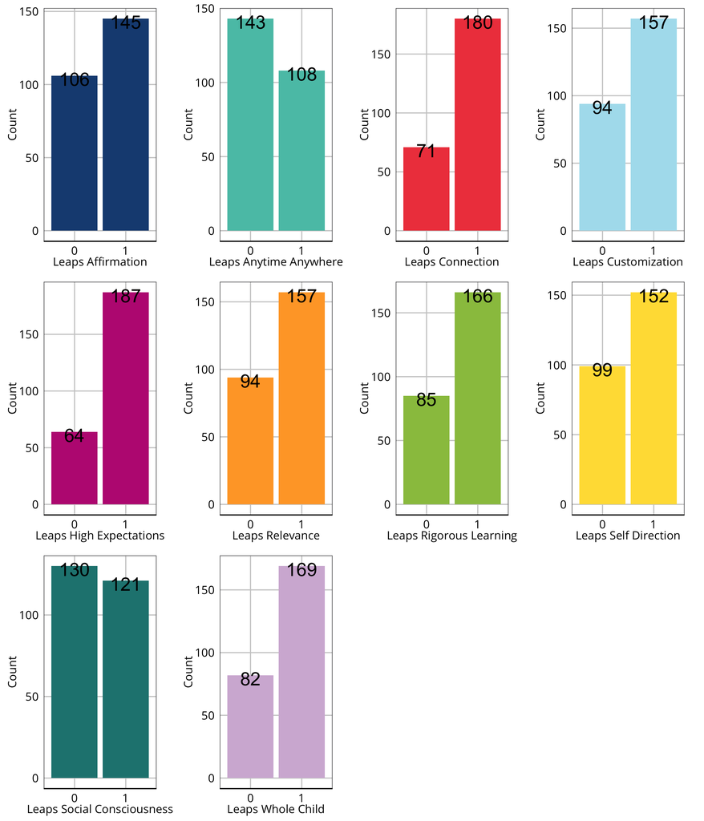

```r
p.1 <- school_leap %>%
  ggplot(aes(x = factor(leaps_affirmation, labels = 0:1)))+
  geom_bar(fill = "#1A4C81")+
    labs(x="Leaps Affirmation", y = "Count")+
    geom_text(
    stat = "count",
    aes(label = after_stat(count)),
    vjust = 0.75,
    color = "black",
    size = 8
  ) +
  scale_x_discrete(labels = c("0", "1"))

p.2 <- school_leap %>%
  ggplot(aes(x = factor(leaps_anytime_anywhere, labels = 0:1)))+
  geom_bar(fill = "#59C3B4")+
    labs(x="Leaps Anytime Anywhere", y = "Count")+
    geom_text(
    stat = "count",
    aes(label = after_stat(count)),
    vjust = 0.75,
    color = "black",
    size = 8
  ) +
  scale_x_discrete(labels = c("0", "1"))

p.3 <- school_leap %>%
  ggplot(aes(x = factor(leaps_connection, labels = 0:1)))+
  geom_bar(fill = "#EF464B")+
    labs(x="Leaps Connection", y = "Count")+
    geom_text(
    stat = "count",
    aes(label = after_stat(count)),
    vjust = 0.75,
    color = "black",
    size = 8
  ) +
  scale_x_discrete(labels = c("0", "1"))

p.4 <- school_leap %>%
  ggplot(aes(x = factor(leaps_customization, labels = 0:1)))+
  geom_bar(fill = "#ADE0EE")+
    labs(x="Leaps Customization", y = "Count")+
    geom_text(
    stat = "count",
    aes(label = after_stat(count)),
    vjust = 0.75,
    color = "black",
    size = 8
  ) +
  scale_x_discrete(labels = c("0", "1"))

p.5 <- school_leap %>%
  ggplot(aes(x = factor(leaps_high_expectations, labels = 0:1)))+
  geom_bar(fill = "#BC2582") +
    labs(x="Leaps High Expectations", y = "Count")+
    geom_text(
    stat = "count",
    aes(label = after_stat(count)),
    vjust = 0.75,
    color = "black",
    size = 8
  ) +
  scale_x_discrete(labels = c("0", "1"))

p.6 <- school_leap %>%
  ggplot(aes(x = factor(leaps_relevance, labels = 0:1)))+
  geom_bar(fill = "#FFA630") +
    labs(x="Leaps Relevance", y = "Count")+
    geom_text(
    stat = "count",
    aes(label = after_stat(count)),
    vjust = 0.75,
    color = "black",
    size = 8
  ) +
  scale_x_discrete(labels = c("0", "1"))

p.7 <- school_leap %>%
  ggplot(aes(x = factor(leaps_rigorous_learning, labels = 0:1)))+
  geom_bar(fill = "#99C24D") +
    labs(x="Leaps Rigorous Learning", y = "Count")+
    geom_text(
    stat = "count",
    aes(label = after_stat(count)),
    vjust = 0.75,
    color = "black",
    size = 8
  ) +
  scale_x_discrete(labels = c("0", "1"))

p.8 <- school_leap %>%
  ggplot(aes(x = factor(leaps_self_direction, labels = 0:1)))+
  geom_bar(fill = "#FFDE42") +
    labs(x="Leaps Self Direction", y = "Count")+
    geom_text(
    stat = "count",
    aes(label = after_stat(count)),
    vjust = 0.75,
    color = "black",
    size = 8
  ) +
  scale_x_discrete(labels = c("0", "1"))

p.9 <- school_leap %>%
  ggplot(aes(x = factor(leaps_social_consciousness, labels = 0:1)))+
  geom_bar(fill = "#218380") +
    labs(x="Leaps Social Consciousness", y = "Count")+
    geom_text(
    stat = "count",
    aes(label = after_stat(count)),
    vjust = 0.75,
    color = "black",
    size = 8
  ) +
  scale_x_discrete(labels = c("0", "1"))


p.10 <- school_leap %>%
  ggplot(aes(x = factor(leaps_whole_child, labels = 0:1))) +
  geom_bar(fill = "#D3B7D7") +
  labs(x="Leaps Whole Child", y = "Count")+
  geom_text(
    stat = "count",
    aes(label = after_stat(count)),
    vjust = 0.75,
    color = "black",
    size = 8
  ) +
  scale_x_discrete(labels = c("0", "1"))




ggarrange(p.1, p.2, p.3, p.4, p.5, p.6, p.7, p.8, p.9, p.10, nrow = 3, ncol = 4)
```

### Percentages

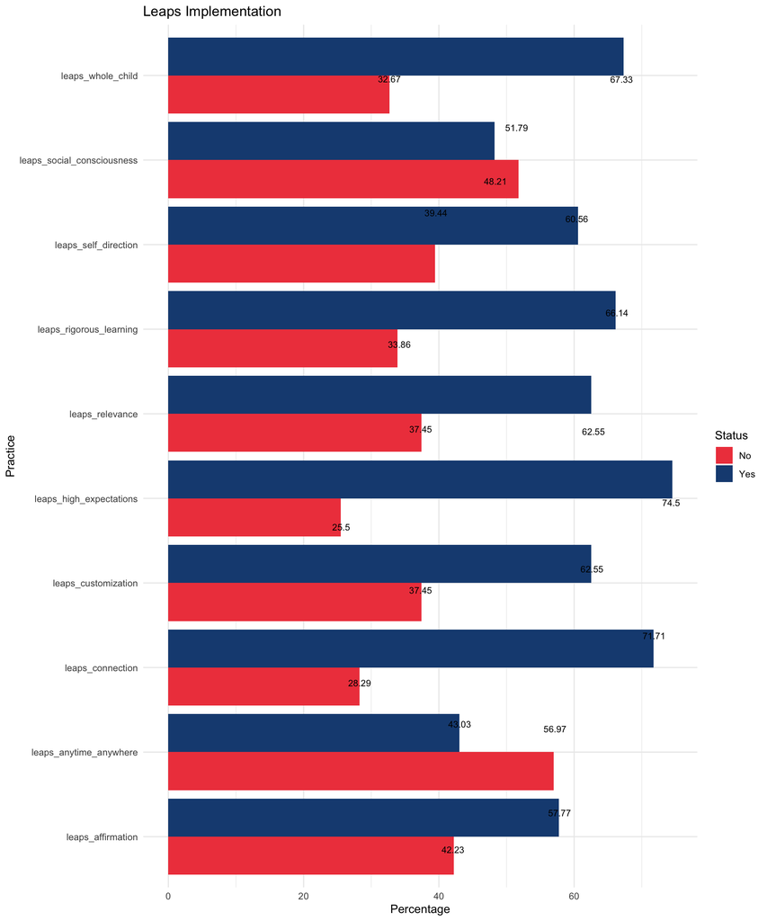

```r
library(gridExtra)


leaps_percentage <- data.frame(
  name = character(),
  percent_yes = numeric(),
  percent_no = numeric(),
  stringsAsFactors = FALSE
)

for (i in leaps_cols){
percent_yes <- round(sum(school_leap[[i]])/length(school_leap[[i]]) *100,2)

percent_no <- round((length(school_leap[[i]]) - sum(school_leap[[i]]))/length(school_leap[[i]])*100, 2)

leaps_percentage <- rbind(leaps_percentage, data.frame(name = i, percent_yes = percent_yes, percent_no = percent_no))

}


leaps_percentage_long <- leaps_percentage %>%
  pivot_longer(cols = c("percent_yes", "percent_no"), names_to = "Status", values_to = "Percentage")

# Create a grouped bar plot
ggplot(leaps_percentage_long, aes(x = name, y = Percentage, fill = Status)) +
  geom_bar(stat = "identity", position = "dodge") +
  geom_text(aes(label = Percentage), color = "black", size = 3, position = "jitter") +
  theme_minimal() +
  labs(title = "Leaps Implementation", x = "Practice", y = "Percentage") +
  scale_fill_manual(values = c("percent_yes" = "#1A4C81", "percent_no" = "#EF464B"), labels = c("No", "Yes")) +
  coord_flip()
```

## Distribution of LEAP Rankings

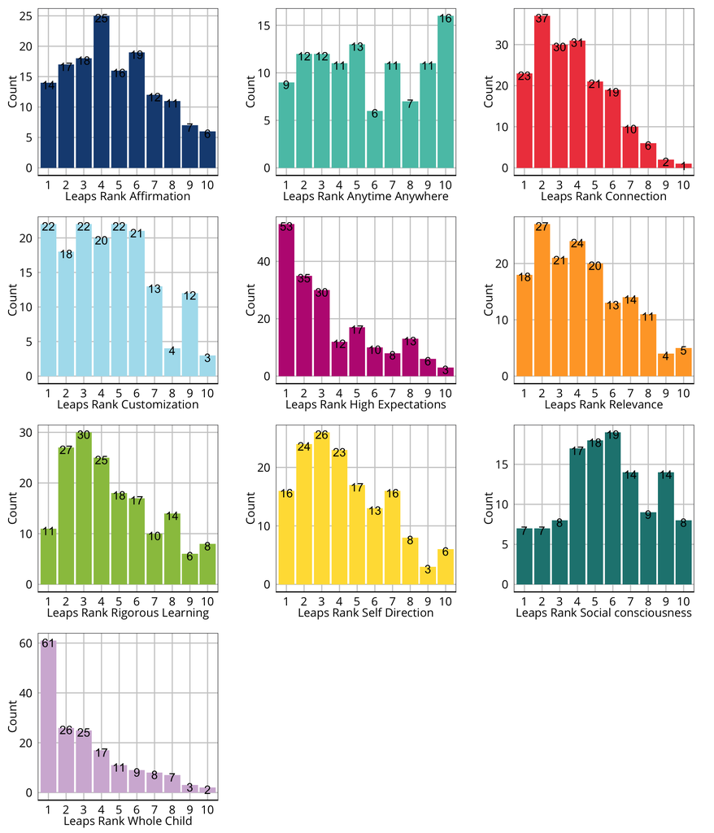

```r
library(gridExtra)

p1 <- school_leap %>%
  filter(!is.na(leaps_rank_affirmation)) %>%
  ggplot(aes(x = factor(leaps_rank_affirmation, labels = 1:10)))+
  geom_bar(fill = "#1A4C81")+
  labs(x="Leaps Rank Affirmation", y = "Count")+
    geom_text(
    stat = "count",
    aes(label = after_stat(count)),
    vjust = 0.75,
    color = "black",
    size = 5
  ) +
  scale_x_discrete(labels = 1:10)


p2 <- school_leap %>%
  filter(!is.na(leaps_rank_anytime_anywhere)) %>%
  ggplot(aes(x = factor(leaps_rank_anytime_anywhere, labels = 1:10)))+
  geom_bar(fill = "#59C3B4")+
    labs(x="Leaps Rank Anytime Anywhere", y = "Count")+
    geom_text(
    stat = "count",
    aes(label = after_stat(count)),
    vjust = 0.75,
    color = "black",
    size = 5
  ) +
  scale_x_discrete(labels = 1:10)


p3 <- school_leap %>%
  filter(!is.na(leaps_rank_connection)) %>%
  ggplot(aes(x = factor(leaps_rank_connection,labels = 1:10)))+
  geom_bar(fill = "#EF464B")+
      labs(x="Leaps Rank Connection", y = "Count")+
    geom_text(
    stat = "count",
    aes(label = after_stat(count)),
    vjust = 0.75,
    color = "black",
    size = 5
  ) +
  scale_x_discrete(labels = 1:10)

p4 <- school_leap %>%
  filter(!is.na(leaps_rank_customization)) %>%
  ggplot(aes(x = factor(leaps_rank_customization, label =1:10)))+
  geom_bar(fill = "#ADE0EE")+
      labs(x="Leaps Rank Customization", y = "Count")+
    geom_text(
    stat = "count",
    aes(label = after_stat(count)),
    vjust = 0.75,
    color = "black",
    size = 5
  ) +
  scale_x_discrete(labels = 1:10)

p5 <- school_leap %>%
  filter(!is.na(leaps_rank_high_expectations)) %>%
  ggplot(aes(x = factor(leaps_rank_high_expectations, labels = 1:10)))+
  geom_bar(fill = "#BC2582")+
      labs(x="Leaps Rank High Expectations", y = "Count")+
    geom_text(
    stat = "count",
    aes(label = after_stat(count)),
    vjust = 0.75,
    color = "black",
    size = 5
  ) +
  scale_x_discrete(labels = 1:10)

p6 <- school_leap %>%
  filter(!is.na(leaps_rank_relevance)) %>%
  ggplot(aes(x = factor(leaps_rank_relevance, labels=1:10)))+
  geom_bar(fill = "#FFA630")+
      labs(x="Leaps Rank Relevance", y = "Count")+
    geom_text(
    stat = "count",
    aes(label = after_stat(count)),
    vjust = 0.75,
    color = "black",
    size = 5
  ) +
  scale_x_discrete(labels = 1:10)

p7 <- school_leap %>%
  filter(!is.na(leaps_rank_rigorous_learning))%>%
  ggplot(aes(x = factor(leaps_rank_rigorous_learning, labels = 1:10)))+
  geom_bar(fill = "#99C24D")+
      labs(x="Leaps Rank Rigorous Learning", y = "Count")+
    geom_text(
    stat = "count",
    aes(label = after_stat(count)),
    vjust = 0.75,
    color = "black",
    size = 5
  ) +
  scale_x_discrete(labels = 1:10)

p8 <- school_leap %>%
  filter(!is.na(leaps_rank_self_direction)) %>%
  ggplot(aes(x = factor(leaps_rank_self_direction, labels = 1:10)))+
  geom_bar(fill = "#FFDE42")+
      labs(x="Leaps Rank Self Direction", y = "Count")+
    geom_text(
    stat = "count",
    aes(label = after_stat(count)),
    vjust = 0.75,
    color = "black",
    size = 5
  ) +
  scale_x_discrete(labels = 1:10)

p9 <- school_leap %>%
  filter(!is.na(leaps_rank_social_consciousness))%>%
  ggplot(aes(x = factor(leaps_rank_social_consciousness, labels = 1:10)))+
  geom_bar(fill = "#218380")+
      labs(x="Leaps Rank Social consciousness", y = "Count")+
    geom_text(
    stat = "count",
    aes(label = after_stat(count)),
    vjust = 0.75,
    color = "black",
    size = 5
  ) +
  scale_x_discrete(labels = 1:10)

p10 <- school_leap %>%
  filter(!is.na(leaps_rank_whole_child))%>%
  ggplot(aes(x = factor(leaps_rank_whole_child, labels = 1:10)))+
  geom_bar(fill = "#D3B7D7")+
      labs(x="Leaps Rank Whole Child", y = "Count")+
    geom_text(
    stat = "count",
    aes(label = after_stat(count)),
    vjust = 0.75,
    color = "black",
    size = 5
  ) +
  scale_x_discrete(labels = 1:10)

ggarrange(p1, p2, p3, p4, p5, p6, p7, p8, p9, p10, ncol = 3, nrow = 4)
```

# Ranked Leap Tags

I am not sure how to get the branding to work with ggplot. I have tried but I can’t figure out how to get the branding to work right. I have downloaded the fonts too but it doesn’t seem to show the correct font.

Anyway, Whole child was ranked 1 by the most schools. Whereas Rigorous learning was ranked 10 or the least important shift in student experience.

```r
column_sums <- colSums(school_leap[, leaps_rank_cols], na.rm = TRUE)

# Rank the columns based on the lowest sum (ascending order)
ranked_columns <- order(column_sums)

# Create a data frame to store the ranked column information
ranked_data <- data.frame(
  Rank = 1:length(ranked_columns),
  Column = leaps_rank_cols[ranked_columns],
  Sum = column_sums[ranked_columns]
)



# Print the ranked column names and their corresponding sums
for (i in 1:length(ranked_columns)) {
  col_index <- ranked_columns[i]
  col_name <- leaps_rank_cols[col_index]
  col_sum <- column_sums[col_index]
  cat("Rank", i, ":", col_name, "- Sum:", col_sum, "\n")
}
```

```
## Rank 1 : leaps_rank_whole_child - Sum: 524
## Rank 2 : leaps_rank_anytime_anywhere - Sum: 606
## Rank 3 : leaps_rank_high_expectations - Sum: 650
## Rank 4 : leaps_rank_self_direction - Sum: 660
## Rank 5 : leaps_rank_connection - Sum: 676
## Rank 6 : leaps_rank_relevance - Sum: 681
## Rank 7 : leaps_rank_affirmation - Sum: 691
## Rank 8 : leaps_rank_social_consciousness - Sum: 693
## Rank 9 : leaps_rank_customization - Sum: 701
## Rank 10 : leaps_rank_rigorous_learning - Sum: 763
```

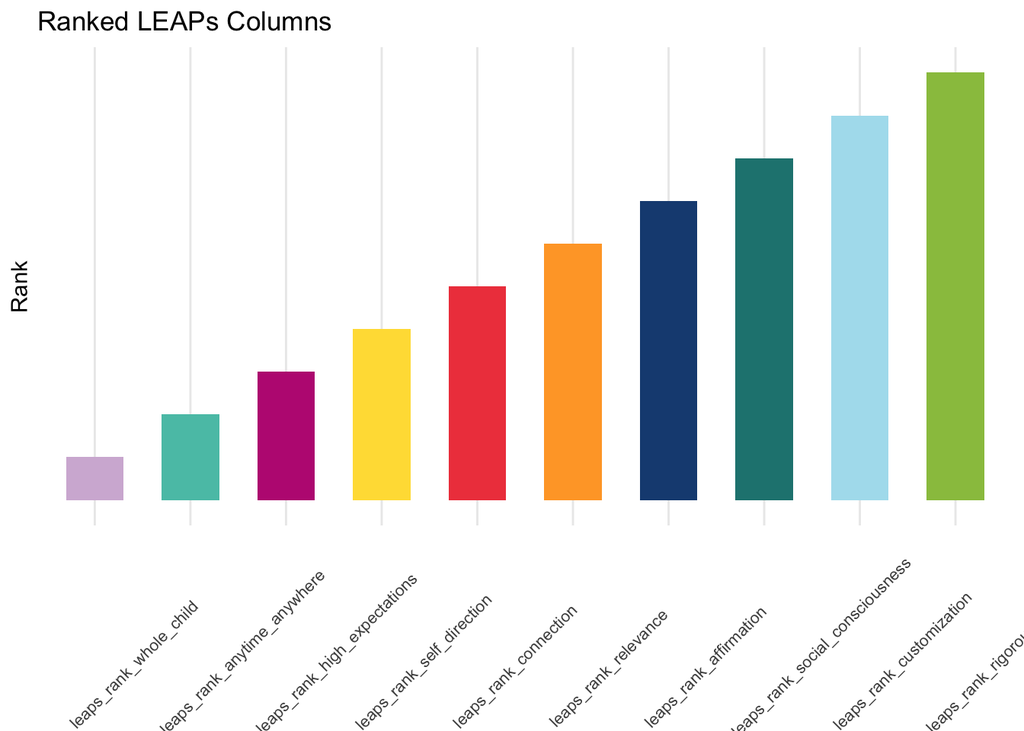

```r
bar_colors <- c("#1A4C81", "#59C3B4", "#EF464B", "#ADE0EE", "#BC2582", "#FFA630", "#99C24D", "#FFDE42", "#218380", "#D3B7D7")  # Color palette for the bars

ggplot(ranked_data, aes(x = reorder(Column,Rank), y = Rank, fill = Column)) +
  geom_col() +
  theme_minimal() +
  theme(axis.text.x = element_text(angle = 45, vjust = 0.05, hjust = 0.15, size = 8),
        legend.position = "none") +
  labs(title = "Ranked LEAPs Columns", x = NULL, y = "Rank") +
  scale_fill_manual(values = bar_colors) +
  scale_y_discrete(breaks = c(1, 10))
```

# Leap Tags Implemenetation

For this I just did a count because it was 1 or 0 where 1 was implementation of a practice so practices with higher scores meant that they were reported to be implemented more often.

```r
Leaps_sums <- colSums(school_leap[, leaps_cols], na.rm = TRUE)

# Rank the columns based on the lowest sum (ascending order)
summed_columns <- order(Leaps_sums, decreasing = TRUE)

# Create a data frame to store the ranked column information
Leaps_data <- data.frame(
  Column = leaps_cols[summed_columns],
  Sum = Leaps_sums[summed_columns]
)



# Print the ranked column names and their corresponding sums
for (i in 1:length(summed_columns)) {
  col_index <- summed_columns[i]
  col_name <- leaps_cols[col_index]
  col_sum <- Leaps_sums[col_index]
  cat("Rank", i, ":", col_name, "- Sum:", col_sum, "\n")
}
```

```
## Rank 1 : leaps_high_expectations - Sum: 187
## Rank 2 : leaps_connection - Sum: 180
## Rank 3 : leaps_whole_child - Sum: 169
## Rank 4 : leaps_rigorous_learning - Sum: 166
## Rank 5 : leaps_customization - Sum: 157
## Rank 6 : leaps_relevance - Sum: 157
## Rank 7 : leaps_self_direction - Sum: 152
## Rank 8 : leaps_affirmation - Sum: 145
## Rank 9 : leaps_social_consciousness - Sum: 121
## Rank 10 : leaps_anytime_anywhere - Sum: 108
```

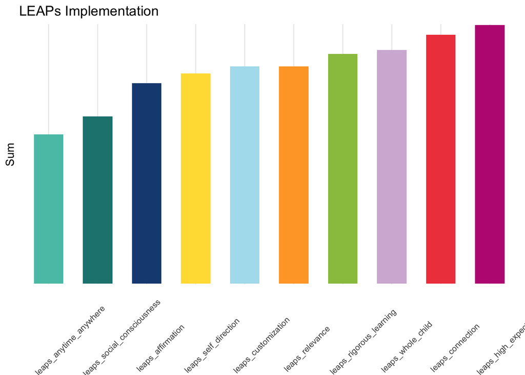

```r
ggplot(Leaps_data, aes(x = reorder(Column,Sum), y = Sum, fill = Column)) +
  geom_col() +
  theme_minimal() +
  theme(axis.text.x = element_text(angle = 45, vjust = 0.05, hjust = 0.15, size = 8),
        legend.position = "none") +
  labs(title = "LEAPs Implementation", x = NULL, y = "Sum") +
  scale_fill_manual(values = bar_colors) +
  scale_y_discrete(breaks = c(1, 10))
```

The Anytime Anywhere practice and Social Consciousness practice were the least commonly picked practices. They were the only ones that were implemented less than 50% of the time. High expectations and Connection were the practices that were most likely to be in implementation.

## Implementation by locale

First I need to bring in the locale code to recode those variables

In Progress still

```r
# Recoding the location variables for rural schools
school_leap <- school_leap %>%
  mutate(rural = recode(self_reported_locale_rural,
                                             "0" = "No",
                                             "1" = "Yes"))
# Recoding the location variables for suburban schools
school_leap <- school_leap %>%
  mutate(suburban = recode(self_reported_locale_suburban,
                                             "0" = "No",
                                             "1" = "Yes"))
# Recoding the location variables for urban schools
school_leap <- school_leap %>%
  mutate(urban = recode(self_reported_locale_urban,
                                             "0" = "No",
                                             "1" = "Yes"))

# Recoding the location variables into one location column
school_leap <- school_leap %>%
  mutate(location = case_when(
    rural == "Yes" & urban == "No" & suburban == "No" ~ "Rural",
    rural == "No" & urban == "Yes" & suburban == "No" ~ "Urban",
    rural == "No" & urban == "No" & suburban == "Yes" ~ "Suburban",
    TRUE ~ "Multiple"  # add an "Other" category for rows that don't fit any of the above conditions
  ))
```

### Counts of implementation by locale

We can see that there are more urban schools then others and they seem to set the trend for the counts and whether there is a big discrepancy in if the practice is implemented or not.

[output not shown]

[output cut: 97 more lines]

[output not shown]

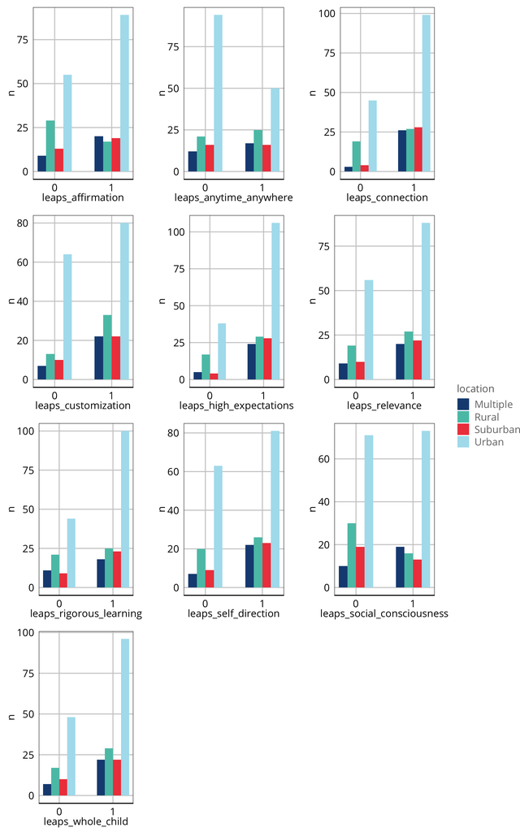

```r
library(ggpubr)

p1 <- school_leap %>%
  group_by(location)%>%
  count(leaps_affirmation)%>%
  ggplot(aes(x = leaps_affirmation, y = n, fill = location))+
  geom_col(position = "dodge")+
  scale_fill_manual(values = transcend_cols)+
  scale_x_continuous(breaks = c(0, 1))

p2 <- school_leap %>%
  group_by(location)%>%
  count(leaps_anytime_anywhere)%>%
  ggplot(aes(x = leaps_anytime_anywhere, y = n, fill = location))+
  geom_col(position = "dodge")+
  scale_fill_manual(values = transcend_cols)+
  scale_x_continuous(breaks = c(0, 1))


p3 <- school_leap %>%
  group_by(location)%>%
  count(leaps_connection)%>%
  ggplot(aes(x = leaps_connection, y = n, fill = location))+
  geom_col(position = "dodge")+
  scale_fill_manual(values = transcend_cols)+
  scale_x_continuous(breaks = c(0, 1))

p4 <- school_leap %>%
  group_by(location)%>%
  count(leaps_customization)%>%
  ggplot(aes(x = leaps_customization, y = n, fill = location))+
  geom_col(position = "dodge")+
  scale_fill_manual(values = transcend_cols)+
  scale_x_continuous(breaks = c(0, 1))

p5 <- school_leap %>%
  group_by(location)%>%
  count(leaps_high_expectations)%>%
  ggplot(aes(x = leaps_high_expectations, y = n, fill = location))+
  geom_col(position = "dodge")+
  scale_fill_manual(values = transcend_cols)+
  scale_x_continuous(breaks = c(0, 1))

p6 <- school_leap %>%
  group_by(location)%>%
  count(leaps_relevance)%>%
  ggplot(aes(x = leaps_relevance, y = n, fill = location))+
  geom_col(position = "dodge")+
  scale_fill_manual(values = transcend_cols)+
  scale_x_continuous(breaks = c(0, 1))

p7 <- school_leap %>%
  group_by(location)%>%
  count(leaps_rigorous_learning)%>%
  ggplot(aes(x = leaps_rigorous_learning, y = n, fill = location))+
  geom_col(position = "dodge")+
  scale_fill_manual(values = transcend_cols)+
  scale_x_continuous(breaks = c(0, 1))

p8 <- school_leap %>%
  group_by(location)%>%
  count(leaps_self_direction)%>%
  ggplot(aes(x = leaps_self_direction, y = n, fill = location))+
  geom_col(position = "dodge")+
  scale_fill_manual(values = transcend_cols)+
  scale_x_continuous(breaks = c(0, 1))

p9 <- school_leap %>%
  group_by(location)%>%
  count(leaps_social_consciousness)%>%
  ggplot(aes(x = leaps_social_consciousness, y = n, fill = location))+
  geom_col(position = "dodge")+
  scale_fill_manual(values = transcend_cols)+
  scale_x_continuous(breaks = c(0, 1))

p10 <- school_leap %>%
  group_by(location)%>%
  count(leaps_whole_child)%>%
  ggplot(aes(x = leaps_whole_child, y = n, fill = location))+
  geom_col(position = "dodge")+
  scale_fill_manual(values = transcend_cols)+
  scale_x_continuous(breaks = c(0, 1))


ggarrange(p1, p2, p3, p4, p5, p6, p7, p8, p9, p10, ncol = 3, nrow = 4, common.legend = TRUE, legend = "right")
```

Here is a table showing the counts by locale and by variable

```r
library(DT)

locale_leap_counts <- school_leap %>%
  select(c(1,2,24:28,30:34,54))


# Reshape data from wide to long format
locale_leap_long <- pivot_longer(locale_leap_counts, cols = starts_with("leaps_"), names_to = "practice", values_to = "value")

# Group by location and practice, and calculate counts
table_counts <- locale_leap_long %>%
  group_by(location, practice) %>%
  summarise(count = sum(value))
# View the resulting table
datatable(table_counts)
```

|  | location | practice | count |
| --- | --- | --- | --- |
| 1 | Multiple | leaps_affirmation | 20 |
| 2 | Multiple | leaps_anytime_anywhere | 17 |
| 3 | Multiple | leaps_connection | 26 |
| 4 | Multiple | leaps_customization | 22 |
| 5 | Multiple | leaps_high_expectations | 24 |
| 6 | Multiple | leaps_relevance | 20 |
| 7 | Multiple | leaps_rigorous_learning | 18 |
| 8 | Multiple | leaps_self_direction | 22 |
| 9 | Multiple | leaps_social_consciousness | 19 |
| 10 | Multiple | leaps_whole_child | 22 |

[output cut: 30 more lines]